# Data Exploration Red Wine Quality

# Bivariate Plots Section

### Coefficient matrix

```
##                      fixed.acidity volatile.acidity citric.acid
## fixed.acidity                 1.00            -0.26        0.67
## volatile.acidity             -0.26             1.00       -0.55
## citric.acid                   0.67            -0.55        1.00
## residual.sugar                0.11             0.00        0.14
## chlorides                     0.09             0.06        0.20
## free.sulfur.dioxide          -0.15            -0.01       -0.06
## total.sulfur.dioxide         -0.11             0.08        0.04
## density                       0.67             0.02        0.36
## pH                           -0.68             0.23       -0.54
## sulphates                     0.18            -0.26        0.31
## alcohol                      -0.06            -0.20        0.11
## quality                       0.12            -0.39        0.23
## bound.sulfur.dioxide         -0.08             0.10        0.07
##                      residual.sugar chlorides free.sulfur.dioxide
## fixed.acidity                  0.11      0.09               -0.15
## volatile.acidity               0.00      0.06               -0.01
## citric.acid                    0.14      0.20               -0.06
## residual.sugar                 1.00      0.06                0.19
## chlorides                      0.06      1.00                0.01
## free.sulfur.dioxide            0.19      0.01                1.00
## total.sulfur.dioxide           0.20      0.05                0.67
## density                        0.36      0.20               -0.02
## pH                            -0.09     -0.27                0.07
## sulphates                      0.01      0.37                0.05
## alcohol                        0.04     -0.22               -0.07
## quality                        0.01     -0.13               -0.05
## bound.sulfur.dioxide           0.17      0.06                0.43
##                      total.sulfur.dioxide density    pH sulphates alcohol
## fixed.acidity                       -0.11    0.67 -0.68      0.18   -0.06
## volatile.acidity                     0.08    0.02  0.23     -0.26   -0.20
## citric.acid                          0.04    0.36 -0.54      0.31    0.11
## residual.sugar                       0.20    0.36 -0.09      0.01    0.04
## chlorides                            0.05    0.20 -0.27      0.37   -0.22
## free.sulfur.dioxide                  0.67   -0.02  0.07      0.05   -0.07
## total.sulfur.dioxide                 1.00    0.07 -0.07      0.04   -0.21
## density                              0.07    1.00 -0.34      0.15   -0.50
## pH                                  -0.07   -0.34  1.00     -0.20    0.21
## sulphates                            0.04    0.15 -0.20      1.00    0.09
## alcohol                             -0.21   -0.50  0.21      0.09    1.00
## quality                             -0.19   -0.17 -0.06      0.25    0.48
## bound.sulfur.dioxide                 0.96    0.10 -0.11      0.03   -0.22
##                      quality bound.sulfur.dioxide
## fixed.acidity           0.12                -0.08
## volatile.acidity       -0.39                 0.10
## citric.acid             0.23                 0.07
## residual.sugar          0.01                 0.17
## chlorides              -0.13                 0.06
## free.sulfur.dioxide    -0.05                 0.43
## total.sulfur.dioxide   -0.19                 0.96
## density                -0.17                 0.10
## pH                     -0.06                -0.11
## sulphates               0.25                 0.03
## alcohol                 0.48                -0.22
## quality                 1.00                -0.21
## bound.sulfur.dioxide   -0.21                 1.00
```

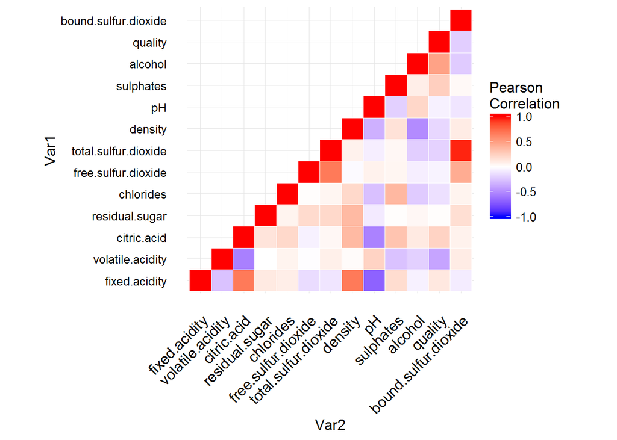

From the correlation matrix, pH, residual sugar and free sulfur dioxide seem to have no correlations with quality, but quality has a negative moderate relationship with volatile acidity (-0.39), a positive moderate relationship (+0.48) with alcohol and a positive weak relationship with citric acid (0.23).

Apart from the positive strong relationship between total sulfur dioxide and bound sulfur dioxide due to the previous calculation, there are three strong relationships in this data sets that I want to explore: a strong negative relationship (-0.50) between alcohol and density. a strong negative relationship (-0.55) between volatile.acidity and citric.acid. a strong negative relationship (-0.54) between pH and citric.acid,

### Quality with alcohol, volatile acidity and citric acid

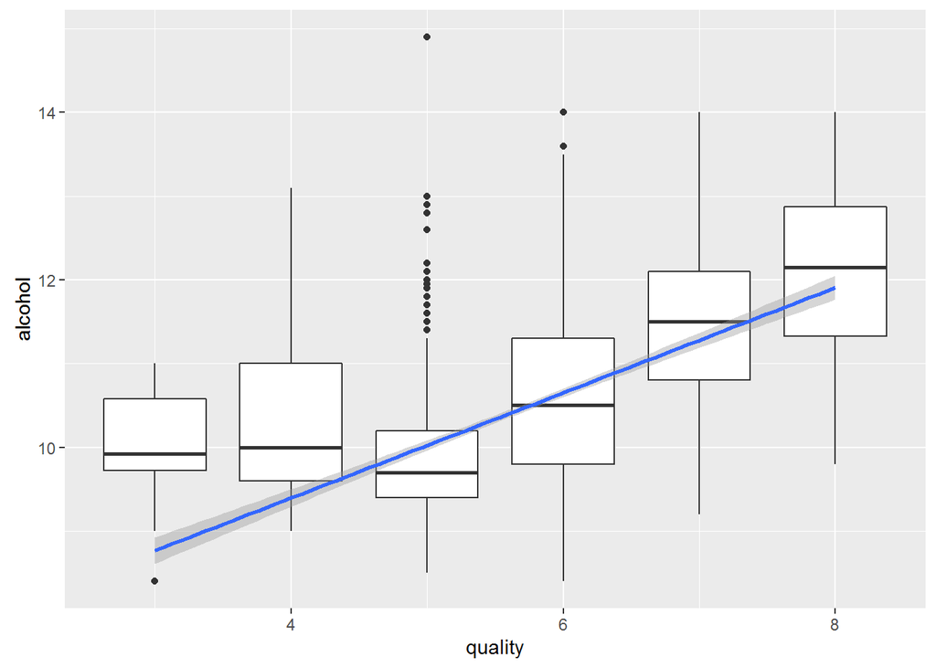

```
## wqr$quality: 3
##    Min. 1st Qu.  Median    Mean 3rd Qu.    Max.
##   8.400   9.725   9.925   9.955  10.580  11.000
## --------------------------------------------------------
## wqr$quality: 4
##    Min. 1st Qu.  Median    Mean 3rd Qu.    Max.
##    9.00    9.60   10.00   10.27   11.00   13.10
## --------------------------------------------------------
## wqr$quality: 5
##    Min. 1st Qu.  Median    Mean 3rd Qu.    Max.
##     8.5     9.4     9.7     9.9    10.2    14.9
## --------------------------------------------------------
## wqr$quality: 6
##    Min. 1st Qu.  Median    Mean 3rd Qu.    Max.
##    8.40    9.80   10.50   10.63   11.30   14.00
## --------------------------------------------------------
## wqr$quality: 7
##    Min. 1st Qu.  Median    Mean 3rd Qu.    Max.
##    9.20   10.80   11.50   11.47   12.10   14.00
## --------------------------------------------------------
## wqr$quality: 8
##    Min. 1st Qu.  Median    Mean 3rd Qu.    Max.
##    9.80   11.32   12.15   12.09   12.88   14.00
```

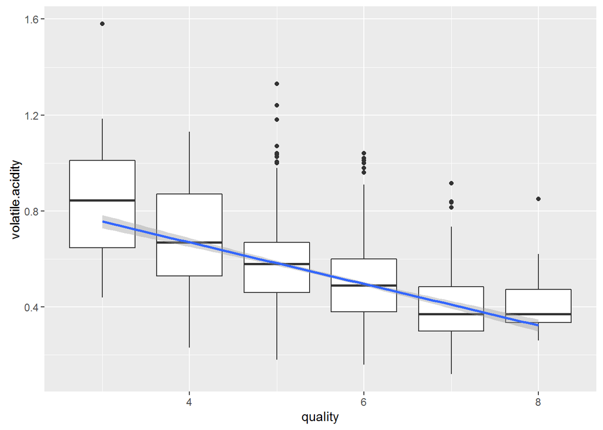

```
## wqr$quality: 3
##    Min. 1st Qu.  Median    Mean 3rd Qu.    Max.
##  0.4400  0.6475  0.8450  0.8845  1.0100  1.5800
## --------------------------------------------------------
## wqr$quality: 4
##    Min. 1st Qu.  Median    Mean 3rd Qu.    Max.
##   0.230   0.530   0.670   0.694   0.870   1.130
## --------------------------------------------------------
## wqr$quality: 5
##    Min. 1st Qu.  Median    Mean 3rd Qu.    Max.
##   0.180   0.460   0.580   0.577   0.670   1.330
## --------------------------------------------------------
## wqr$quality: 6
##    Min. 1st Qu.  Median    Mean 3rd Qu.    Max.
##  0.1600  0.3800  0.4900  0.4975  0.6000  1.0400
## --------------------------------------------------------
## wqr$quality: 7
##    Min. 1st Qu.  Median    Mean 3rd Qu.    Max.
##  0.1200  0.3000  0.3700  0.4039  0.4850  0.9150
## --------------------------------------------------------
## wqr$quality: 8
##    Min. 1st Qu.  Median    Mean 3rd Qu.    Max.
##  0.2600  0.3350  0.3700  0.4233  0.4725  0.8500
```

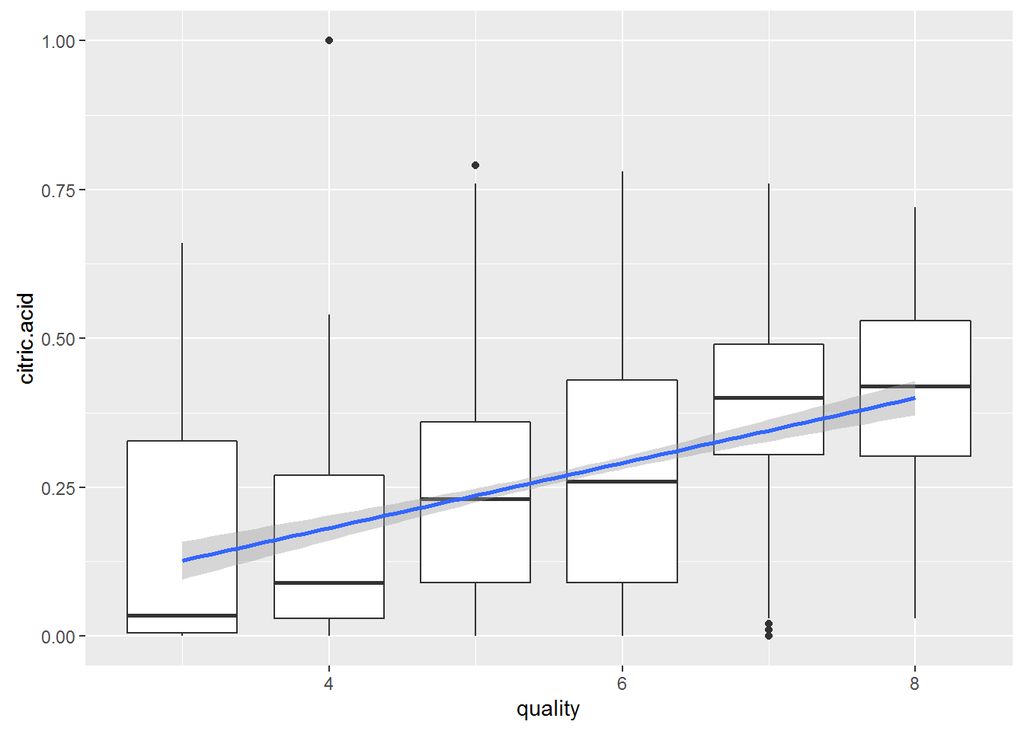

```
## wqr$quality: 3
##    Min. 1st Qu.  Median    Mean 3rd Qu.    Max.
##  0.0000  0.0050  0.0350  0.1710  0.3275  0.6600
## --------------------------------------------------------
## wqr$quality: 4
##    Min. 1st Qu.  Median    Mean 3rd Qu.    Max.
##  0.0000  0.0300  0.0900  0.1742  0.2700  1.0000
## --------------------------------------------------------
## wqr$quality: 5
##    Min. 1st Qu.  Median    Mean 3rd Qu.    Max.
##  0.0000  0.0900  0.2300  0.2437  0.3600  0.7900
## --------------------------------------------------------
## wqr$quality: 6
##    Min. 1st Qu.  Median    Mean 3rd Qu.    Max.
##  0.0000  0.0900  0.2600  0.2738  0.4300  0.7800
## --------------------------------------------------------
## wqr$quality: 7
##    Min. 1st Qu.  Median    Mean 3rd Qu.    Max.
##  0.0000  0.3050  0.4000  0.3752  0.4900  0.7600
## --------------------------------------------------------
## wqr$quality: 8
##    Min. 1st Qu.  Median    Mean 3rd Qu.    Max.
##  0.0300  0.3025  0.4200  0.3911  0.5300  0.7200
```

The trend between quality and alcohol is very clear that when the alcohol percentage increases the quality improves. The relationship between quality and volatile acidity is negative, which means better quality is observed in lower volatile acidity. The slope is less steep between quality and citric acid, but it shows a higher level of citric acid contributes to a better quality of wine.

### Density & alcohol

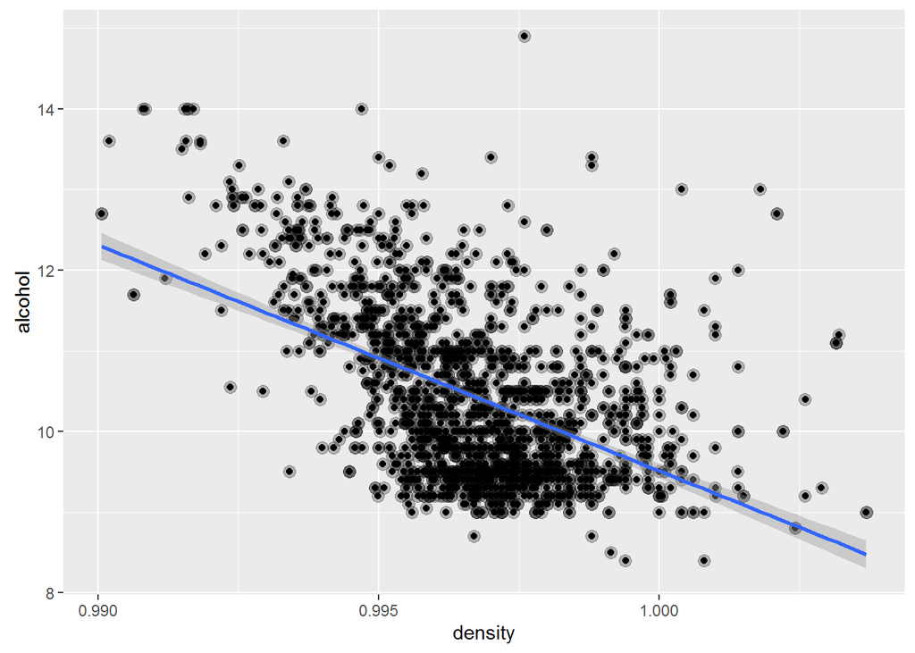

```
##
##  Pearson's product-moment correlation
##
## data:  wqr$density and wqr$alcohol
## t = -22.838, df = 1597, p-value < 2.2e-16
## alternative hypothesis: true correlation is not equal to 0
## 95 percent confidence interval:
##  -0.5322547 -0.4583061
## sample estimates:
##        cor
## -0.4961798
```

When density increases, the alcohol level decreases.

### Volatile acidity & citric acid

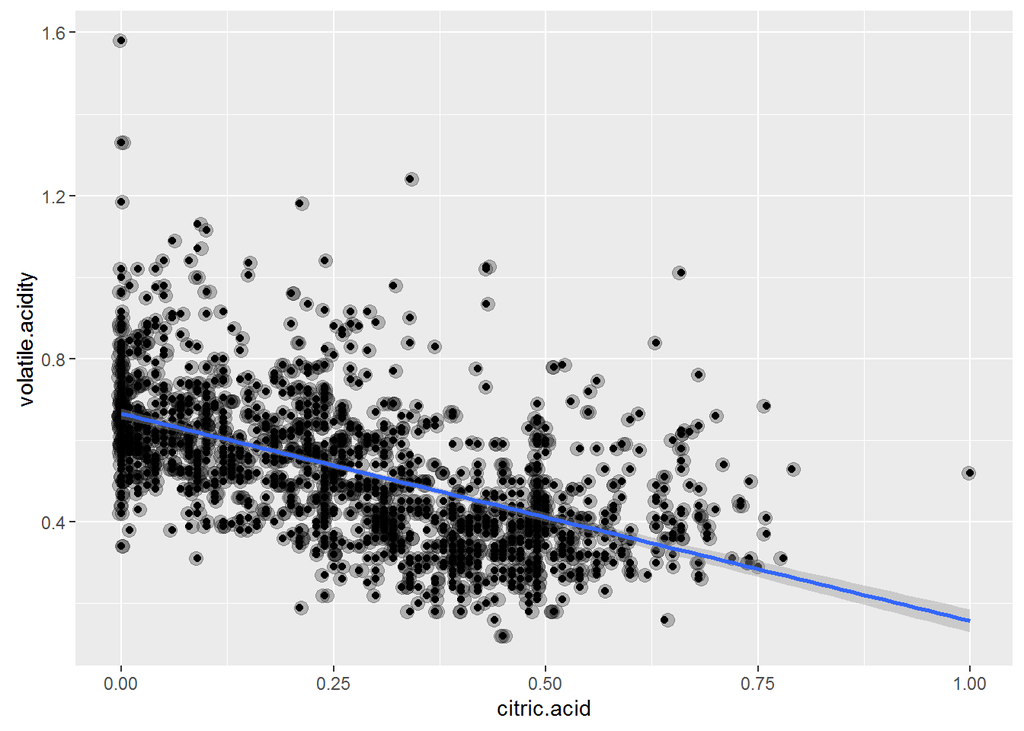

```
##
##  Pearson's product-moment correlation
##
## data:  wqr$citric.acid and wqr$volatile.acidity
## t = -26.489, df = 1597, p-value < 2.2e-16
## alternative hypothesis: true correlation is not equal to 0
## 95 percent confidence interval:
##  -0.5856550 -0.5174902
## sample estimates:
##        cor
## -0.5524957
```

Volatile acidity and citric acid also demonstrated a negative relationship. It is interesting to see that both variables are related to quality in some degree: volatile acidity has a negative relationship with quality and citric acid has a positive relationship with quality.

### Fixed acidity & pH

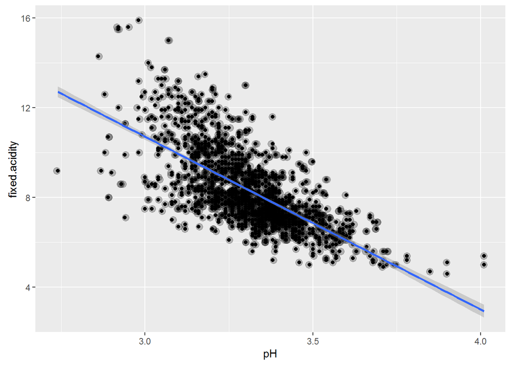

```
##
##  Pearson's product-moment correlation
##
## data:  wqr$pH and wqr$fixed.acidity
## t = -37.366, df = 1597, p-value < 2.2e-16
## alternative hypothesis: true correlation is not equal to 0
## 95 percent confidence interval:
##  -0.7082857 -0.6559174
## sample estimates:
##        cor
## -0.6829782
```

It is not a surprise to see the strongest relationship is between pH and fixed acidity, as pH scale measure how acidic a substance is.

# Bivariate Analysis

### Talk about some of the relationships you observed in this part of the investigation. How did the feature(s) of interest vary with other features in the dataset?

There are only two variables showing a slightly stronger relationship with quality: a negative moderate relationship with volatile acidity (-0.39), a positive moderate relationship (+0.48) with alcohol. Surprisingly, the pH level has a very weak relationship with quality (-0.06).

### What was the strongest relationship you found?

It is obvious that total sulfur dioxide and bound sulfur dioxide have a very strong relationship (+0.96) as it was calculated by subtracting free sulfur dioxide. The strongest relationship is between pH and fixed acidity (-0.68), which is again quite reasonable as pH level goes against fixed acidity.

# Multivariate Plots Section

### Density & alcohol by quality cut

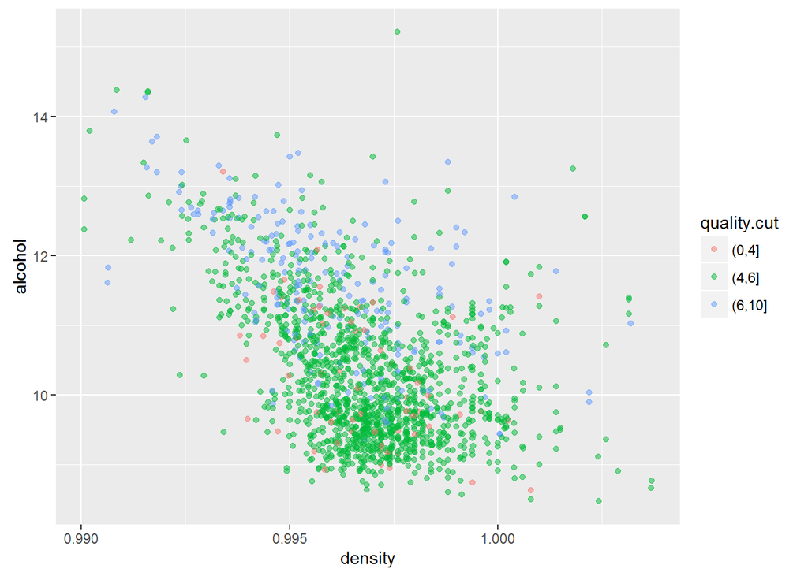

```
## [1] "Mean of density by quality cut"
```

```
## wqr$quality.cut: (0,4]
## [1] 0.9966887
## --------------------------------------------------------
## wqr$quality.cut: (4,6]
## [1] 0.9968673
## --------------------------------------------------------
## wqr$quality.cut: (6,10]
## [1] 0.9960303
```

```
## [1] "Mean of alcohol % by quality cut"
```

```
## wqr$quality.cut: (0,4]
## [1] 10.21587
## --------------------------------------------------------
## wqr$quality.cut: (4,6]
## [1] 10.25272
## --------------------------------------------------------
## wqr$quality.cut: (6,10]
## [1] 11.51805
```

High-quality wine [6,10] have a higher percentage of alcohol with a varied range of density between 0.990 and 1.000. On the other hand, low-quality wine [0,4] has a lower percentage of alcohol with the density in a more defined range of 0.995 and 1.000.

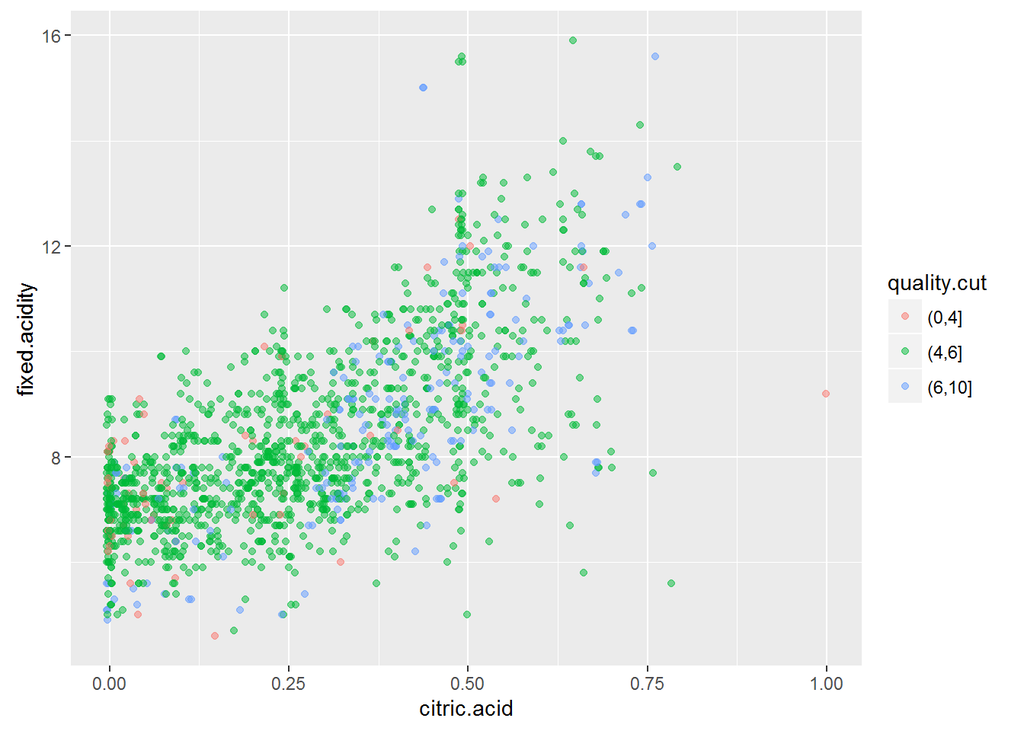

```
## [1] "Mean of fixed acidity by quality cut"
```

```
## wqr$quality.cut: (0,4]
## [1] 7.871429
## --------------------------------------------------------
## wqr$quality.cut: (4,6]
## [1] 8.254284
## --------------------------------------------------------
## wqr$quality.cut: (6,10]
## [1] 8.847005
```

```
## [1] "Mean of citric acid by quality cut"
```

```
## wqr$quality.cut: (0,4]
## [1] 0.1736508
## --------------------------------------------------------
## wqr$quality.cut: (4,6]
## [1] 0.2582638
## --------------------------------------------------------
## wqr$quality.cut: (6,10]
## [1] 0.3764977
```

Low-quality wines see lower fixed acidity, especially with a lower citric acid. High-quality wines have a combination of higher citric acid and higher fixed acidity.

### Citric acid & pH by quality cut

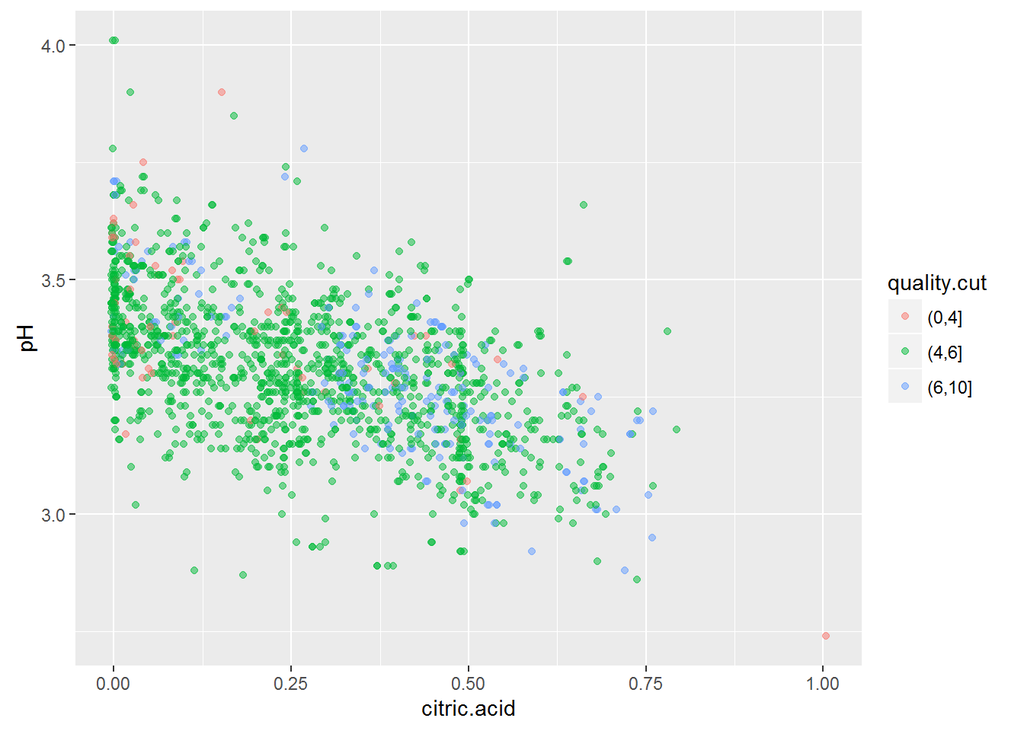

```
## [1] "Mean of pH by quality cut"
```

```
## wqr$quality.cut: (0,4]
## [1] 3.384127
## --------------------------------------------------------
## wqr$quality.cut: (4,6]
## [1] 3.311296
## --------------------------------------------------------
## wqr$quality.cut: (6,10]
## [1] 3.288802
```

```
## [1] "Mean of citric acid by quality cut"
```

```
## wqr$quality.cut: (0,4]
## [1] 0.1736508
## --------------------------------------------------------
## wqr$quality.cut: (4,6]
## [1] 0.2582638
## --------------------------------------------------------
## wqr$quality.cut: (6,10]
## [1] 0.3764977
```

High-quality wines have a combination of lower pH and higher citric acid, while low-quality wines sees a level of higher pH and lower citric acid.

### Free form ratio in total sulfur dioxide and quality

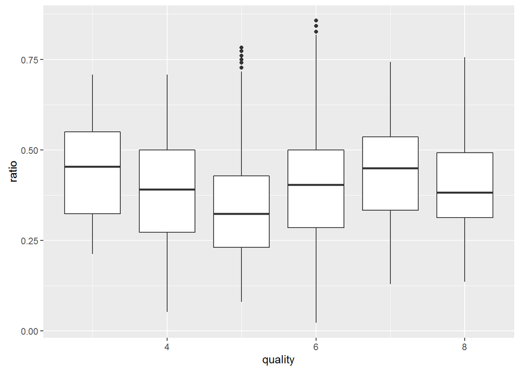

```
##
##  Pearson's product-moment correlation
##
## data:  wqr$ratio and wqr$quality
## t = 7.9077, df = 1597, p-value = 4.854e-15
## alternative hypothesis: true correlation is not equal to 0
## 95 percent confidence interval:
##  0.1464861 0.2408427
## sample estimates:
##       cor
## 0.1941134
```

It does not seem to have any strong relationship (+0.19) between the ratio of a free form of sulfur dioxide and quality of the red wines.

# Multivariate Analysis

### Talk about some of the relationships you observed in this part of the investigation. Were there features that strengthened each other in terms of looking at your feature(s) of interest?

High-quality wines have a combination of lower pH and higher citric acid or a combination of higher citric acid and higher fixed acidity. Low-quality wines see a mix of higher pH and lower citric acid or a mix of lower fixed acidity and lower citric acid.

### Were there any interesting or surprising interactions between features?

# Final Plots and Summary

### Plot One

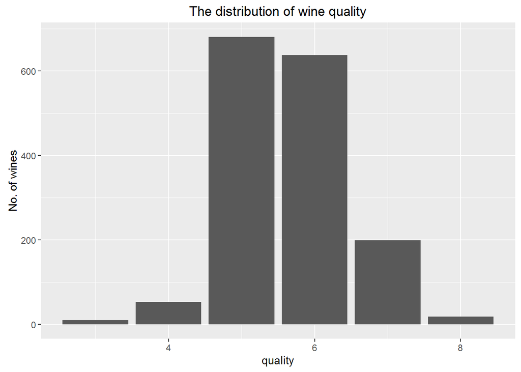

### Description One

A total of 1319 red wine samples (more than 80%) are graded 5 and 6, and there are no wine samples being marked less than 3 or more than 8.

### Plot Two

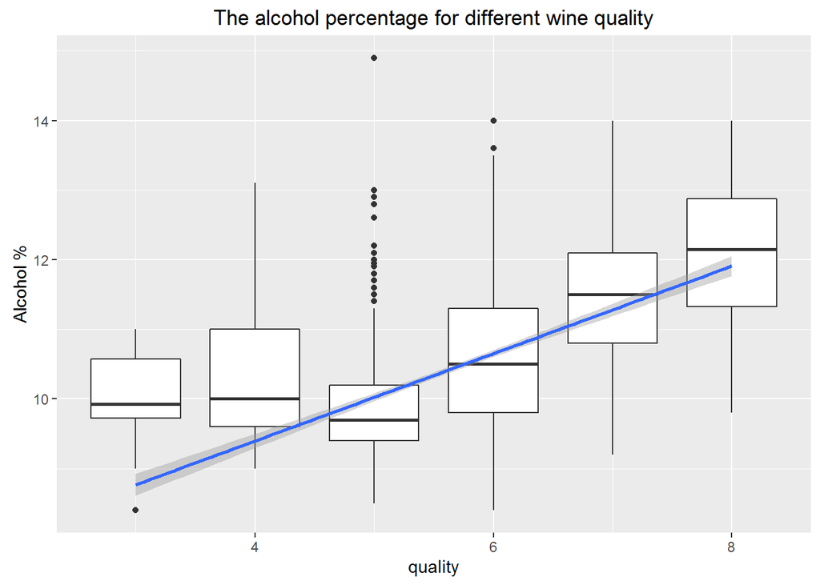

### Plot Three

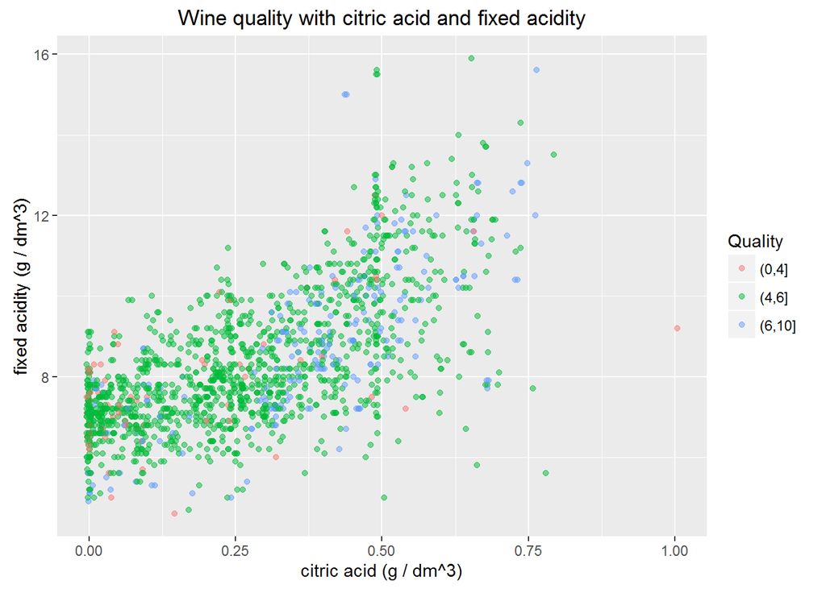

### Description Three

There is a clear pattern that low-quality wines [0,4] tend to have lower fixed acidity and a lower citric acid and high-quality wines [6, 10] have a combination of high citric acid and high fixed acidity. More specifically, low- quality wines have a mean of fixed acidity of 7.87 and a mean of citric acid of 0.17. For high-quality wines have a mean of fixed acidity of 8.84 and a mean of citric acid of 0.37.

# Reflection

I found I don’t need to do data wrangling for this sample data set as it is very tidy. To my surprise, pH level doesn’t have a strong correlation with quality.I also didn’t see any strong correlation between the ratio of a free form of sulfur dioxide and quality of the red wines.

In my bivariate analysis, I discovered alcohol and volatile acidity have a moderate relationship with quality. My multivariate analysis shows high-quality wines have a combination of lower pH and higher citric acid or a combination of higher citric acid and higher fixed acidity. On the other hand, low-quality wines see a mix of higher pH and lower citric acid or a mix of lower fixed acidity and lower citric acid.

However, I don’t think I can confidently say that a certain combination of variables proves to provide good quality wines. It seems like the quality grading by experts doesn’t purely based on 12 variables provided in the data set. It would be interesting to analyse the red quality by the year of production, the place of the product, etc.